# Impact of Weather Events on Health and Economy in U.S.

Utkarsh Chauhan

8/15/2020

## Synopsis

Severe weather events can cause both public health as well a economic problems in communities. In this report, we explore the U.S. National Oceanic and Atmospheric Administration’s (NOAA) storm database from 1950 - 2011. This database tracks characteristics of major storms and weather events in the United States, including when and where they occur, as well as estimates of any fatalities, injuries, and property damage. Using this, we will try to answer which types of events are most harmful with respect to population health and economy.  
The analysis of the data shows that *Tornados* are most harmful with respect to *Population Health*, while *Floods* have the worst *Economic Impact*.

## Setting R Environment, Data Download

```r
library(dplyr)
library(ggplot2)
```

Data is downloaded if it doesn’t exist in current directory.

```r
if ( !file.exists("repdata_data_StormData.csv.bz2") ) {
    download.file('https://d396qusza40orc.cloudfront.net/repdata%2Fdata%2FStormData.csv.bz2', 'repdata_data_StormData.csv.bz2')
}
```

## Loadinf and Examining Data

Loading the data in R environment :

```r
# It may take some time.
data <- read.csv('repdata_data_StormData.csv.bz2')
```

Inspecting the structure of Data :

```r
dim <- dim(data)
summary(data)
```

```
##     STATE__       BGN_DATE           BGN_TIME          TIME_ZONE
##  Min.   : 1.0   Length:902297      Length:902297      Length:902297
##  1st Qu.:19.0   Class :character   Class :character   Class :character
##  Median :30.0   Mode  :character   Mode  :character   Mode  :character
##  Mean   :31.2
##  3rd Qu.:45.0
##  Max.   :95.0
##
##      COUNTY       COUNTYNAME           STATE              EVTYPE
##  Min.   :  0.0   Length:902297      Length:902297      Length:902297
##  1st Qu.: 31.0   Class :character   Class :character   Class :character
##  Median : 75.0   Mode  :character   Mode  :character   Mode  :character
##  Mean   :100.6
##  3rd Qu.:131.0
##  Max.   :873.0
##
##    BGN_RANGE          BGN_AZI           BGN_LOCATI          END_DATE
##  Min.   :   0.000   Length:902297      Length:902297      Length:902297
##  1st Qu.:   0.000   Class :character   Class :character   Class :character
##  Median :   0.000   Mode  :character   Mode  :character   Mode  :character
##  Mean   :   1.484
##  3rd Qu.:   1.000
##  Max.   :3749.000
##
##    END_TIME           COUNTY_END COUNTYENDN       END_RANGE
##  Length:902297      Min.   :0    Mode:logical   Min.   :  0.0000
##  Class :character   1st Qu.:0    NA's:902297    1st Qu.:  0.0000
##  Mode  :character   Median :0                   Median :  0.0000
##                     Mean   :0                   Mean   :  0.9862
##                     3rd Qu.:0                   3rd Qu.:  0.0000
##                     Max.   :0                   Max.   :925.0000
##
##    END_AZI           END_LOCATI            LENGTH              WIDTH
##  Length:902297      Length:902297      Min.   :   0.0000   Min.   :   0.000
##  Class :character   Class :character   1st Qu.:   0.0000   1st Qu.:   0.000
##  Mode  :character   Mode  :character   Median :   0.0000   Median :   0.000
##                                        Mean   :   0.2301   Mean   :   7.503
##                                        3rd Qu.:   0.0000   3rd Qu.:   0.000
##                                        Max.   :2315.0000   Max.   :4400.000
##
```

[output cut: 25 more lines]

```
##  Min.   :-14451   Min.   :   0   Min.   :-14455   Length:902297
##  1st Qu.:  7247   1st Qu.:   0   1st Qu.:     0   Class :character
##  Median :  8707   Median :   0   Median :     0   Mode  :character
##  Mean   :  6940   Mean   :1452   Mean   :  3509
##  3rd Qu.:  9605   3rd Qu.:3549   3rd Qu.:  8735
##  Max.   : 17124   Max.   :9706   Max.   :106220
##                   NA's   :40
##      REFNUM
##  Min.   :     1
##  1st Qu.:225575
##  Median :451149
##  Mean   :451149
##  3rd Qu.:676723
##  Max.   :902297
##
```

Here we can see that the dimension of data is 902297, 37.

## Data Processing

First of all BGN_DATE is converted to date object and white space is trimmed from EVTYPE.

```r
data <- mutate(data, BGN_DATE = as.Date(BGN_DATE,'%m/%d/%Y', tz = TIME_ZONE),
               EVTYPE = trimws(EVTYPE))
```

Now lets plot a histogram of frequency of these events per year.

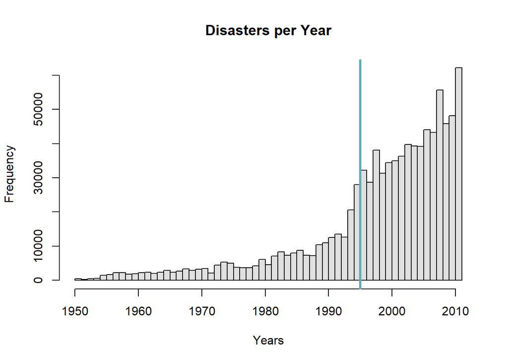

```r
hist(as.numeric(format(data$BGN_DATE,'%Y')),breaks=61, main = 'Disasters per Year',
     xlab = 'Years', col='#e0e0e0')
abline(v=1995,lwd=3,col='#62acb5')
```

```r
data <- select(data, BGN_DATE, EVTYPE, PROPDMG, PROPDMGEXP, CROPDMG,
               CROPDMGEXP, FATALITIES, INJURIES) %>%
    filter(format(BGN_DATE,'%Y') > 1995) %>%
    filter(FATALITIES > 0 | INJURIES > 0 | PROPDMG > 0 | CROPDMG > 0)
```

For our analysis, columns of interest are:

- BGN_DATE: starting date of event
- EVTYPE: weather event (Tornados, Wind, Snow, Flood, etc..)
- PROPDMG: approx. property damages
- PROPDMGEXP: the units for property damage value
- CROPDMG: approx. crop damages
- CROPDMGEXP: the units for crop damage value
- FATALITIES: approx. number of deaths
- INJURIES: approx. number of injuries

Checking for missing values:

```r
sum(!complete.cases(data))
```

```
## [1] 0
```

This means none of the values in our data set are missing.

Now, we will convert `PROPDMGEXP` and `CROPDMGEXP` into their exponential form.

```r
table(data$PROPDMGEXP)
```

```
##
##             B      K      M
##   8448     32 185474   7364
```

```r
table(data$CROPDMGEXP)
```

```
##
##             B      K      M
## 102767      2  96787   1762
```

These symbols represent the following:

- K: thousand dollars (10^3)
- M: million dollars (10^6)
- B: billion dollars (10^9)

```r
data$PROPDMGEXP[(data$PROPDMGEXP == '')] <- 1
data$PROPDMGEXP[(data$PROPDMGEXP == 'K')] <- 10^3
data$PROPDMGEXP[(data$PROPDMGEXP == 'M')] <- 10^6
data$PROPDMGEXP[data$PROPDMGEXP == 'B'] <- 10^9
data$PROPDMGEXP <- as.numeric(data$PROPDMGEXP)

data$CROPDMGEXP[(data$CROPDMGEXP == '')] <- 1
data$CROPDMGEXP[(data$CROPDMGEXP == 'K')] <- 10^3
data$CROPDMGEXP[(data$CROPDMGEXP == 'M')] <- 10^6
data$CROPDMGEXP[(data$CROPDMGEXP == 'B')] <- 10^9
data$CROPDMGEXP <- as.numeric(data$CROPDMGEXP)
```

This is our clean dataset.

```r
head(data)
```

```
##     BGN_DATE       EVTYPE PROPDMG PROPDMGEXP CROPDMG CROPDMGEXP FATALITIES
## 1 1996-01-06 WINTER STORM     380       1000      38       1000          0
## 2 1996-01-11      TORNADO     100       1000       0          1          0
## 3 1996-01-11    TSTM WIND       3       1000       0          1          0
## 4 1996-01-11    TSTM WIND       5       1000       0          1          0
## 5 1996-01-11    TSTM WIND       2       1000       0          1          0
## 6 1996-01-18    HIGH WIND     400       1000       0          1          0
##   INJURIES
## 1        0
## 2        0
## 3        0
## 4        0
## 5        0
## 6        0
```

```r
tail(data)
```

```
##          BGN_DATE       EVTYPE PROPDMG PROPDMGEXP CROPDMG CROPDMGEXP FATALITIES
## 201313 2011-11-09 WINTER STORM     2.0       1000       0       1000          0
## 201314 2011-11-09 WINTER STORM     5.0       1000       0       1000          0
## 201315 2011-11-23  STRONG WIND     0.6       1000       0       1000          0
## 201316 2011-11-13  STRONG WIND     1.0       1000       0       1000          0
## 201317 2011-11-01      DROUGHT     2.0       1000       0       1000          0
## 201318 2011-11-30    HIGH WIND     7.5       1000       0       1000          0
##        INJURIES
## 201313        0
## 201314        0
## 201315        0
## 201316        0
## 201317        0
## 201318        0
```

```r
str(data)
```

```
## 'data.frame':    201318 obs. of  8 variables:
##  $ BGN_DATE  : Date, format: "1996-01-06" "1996-01-11" ...
##  $ EVTYPE    : chr  "WINTER STORM" "TORNADO" "TSTM WIND" "TSTM WIND" ...
##  $ PROPDMG   : num  380 100 3 5 2 400 12 8 12 75 ...
##  $ PROPDMGEXP: num  1000 1000 1000 1000 1000 1000 1000 1000 1000 1000 ...
##  $ CROPDMG   : num  38 0 0 0 0 0 0 0 0 0 ...
##  $ CROPDMGEXP: num  1000 1 1 1 1 1 1 1 1 1 ...
##  $ FATALITIES: num  0 0 0 0 0 0 0 0 0 0 ...
##  $ INJURIES  : num  0 0 0 0 0 0 0 0 0 0 ...
```

## Results

### Weather events most harmful with respect to population health

```r
health <- group_by(data,EVTYPE) %>%
  summarise(FATALITIES = sum(FATALITIES, na.rm = TRUE),
            INJURIES = sum(INJURIES, na.rm = TRUE)) %>%
  filter(FATALITIES > 0 | INJURIES > 0) %>%
  arrange(desc(FATALITIES+INJURIES))
```

A subset of data is made by grouping it by `EVTYPE` and summarizing `FATALITIES` and `INJURIES` by sum. After that, the data is filtered to contain columns that are required for health impact analysis and then arranged in descending order by `FATALITIES` and `INJURIES`.

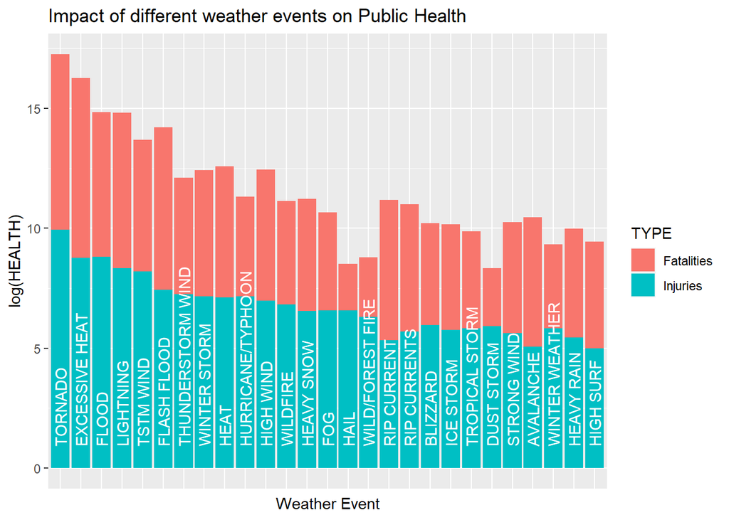

```r
h <- rbind(select(health[1:27,],EVTYPE,FATALITIES) %>% rename(HEALTH = FATALITIES) %>%
           mutate(TYPE='Fatalities'),
         select(health[1:27,],EVTYPE,INJURIES) %>% rename(HEALTH = INJURIES) %>%
           mutate(TYPE='Injuries'))

g <- ggplot(h, aes(x = factor(EVTYPE,levels = health$EVTYPE[1:27],ordered=TRUE),
                   y = log(HEALTH), fill = TYPE)) + geom_bar(stat = "identity")
g + geom_text(stat="count", y=0.9, hjust=0, angle = 90,col='white',
              label=c(rbind(h[1:27,]$EVTYPE,rep('',27)))) +
  theme(axis.text.x=element_blank(),axis.ticks.x=element_blank()) + labs(x='Weather Event') + ggtitle("Impact of different weather events on Public Health")
```

#### This plot shows most *fatality* and *injury* causing Weather Events.

### Weather events worst impactful with respect to economy

```r
economy <- group_by(data,EVTYPE) %>%
  summarise(PROPDMG = sum(PROPDMG*PROPDMGEXP, na.rm = TRUE),
            CROPDMG = sum(CROPDMG*CROPDMGEXP, na.rm = TRUE)) %>%
  filter(PROPDMG > 0 | CROPDMG > 0) %>%
  arrange(desc(PROPDMG+CROPDMG))
```

This time, a subset of data is made by grouping it by `EVTYPE` and summarizing `PROPDMG` and `CROPDMG` by sum after multiplying them with their respective *EXP*. Subsequently, the data is filtered to contain columns that are required for health impact analysis and then arranged in descending order by `PROPDMG` and `CROPDMG`.

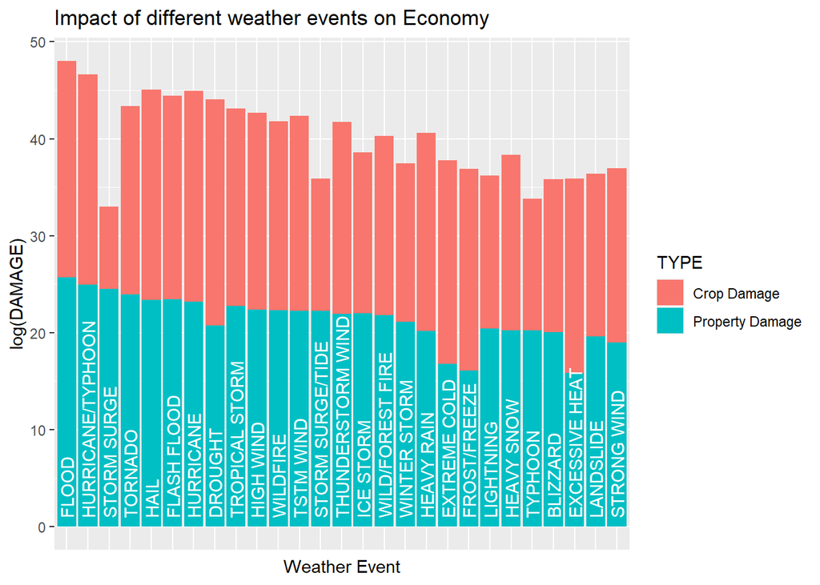

```r
e<-rbind(select(economy[1:27,],EVTYPE,PROPDMG) %>% rename(DAMAGE = PROPDMG) %>%
           mutate(TYPE='Property Damage'),
         select(economy[1:27,],EVTYPE,CROPDMG) %>% rename(DAMAGE = CROPDMG) %>%
           mutate(TYPE='Crop Damage'))

g <- ggplot(e, aes(x = factor(EVTYPE,levels = economy$EVTYPE[1:27],ordered=TRUE),
                     y = log(DAMAGE), fill = TYPE)) + geom_bar(stat = "identity")
g + geom_text(stat="count", y=0.9, hjust=0, angle = 90,col='white',
              label=c(rbind(e[1:27,]$EVTYPE,rep('',27)))) +
  theme(axis.text.x=element_blank(),axis.ticks.x=element_blank()) + labs(x='Weather Event') + ggtitle("Impact of different weather events on Economy")
```

#### This plot shows top Weather Events causing *economical damage*.

## Conclusion

From this data analysis, we found that **Tornados** are most harmful with respect to *population health*, while **Floods** have the worst *economic consequences*.